# MultiSero Tutorial - Malaria Example

Madiha Shafquat

2026-03-06

Here we will use MultiSero to analyze data from the COMSA cross-sectional cohort in Mozambique. Each individual in the dataset has antibody measurements against MSP1-19 antigens from *P. falciparum*, *P. malariae*, *P. ovale*, and *P. vivax*, measured on a multi-antigen Luminex assay. Our primary outputs of interest are *Plasmodium* species-specific seroprevalence and cross-reactivity estimates ($\phi$) for each combination of species.

# Set up

```r
# Required packages for this tutorial
library(here)           # File path management
library(data.table)     # Fast data manipulation
library(tidyverse)      # Data wrangling and visualization (includes ggplot2, dplyr, tidyr)
library(GGally)         # Extension to ggplot2 for pairwise plots
library(bayesplot)      # Visualization of Bayesian models and diagnostics

theme_set(theme_bw())

# source functions
source(here("R", "RFunctions.R"))
```

## Data pre-processing

For input into MultiSero, data should be in wide format, with one row per individual and one column per antigen. The COMSA data has been pre-processed using BREAD and is available as normalized MFI values in long format. t present, it is possible for BREAD to output MFIs that are below 0, but our model uses measurements on the log scale. Here we will only include inviduals with measurements > 0, but a different approach could also be appropriate depending on the dataset.

```r
# read in data
bread_raw <- read.csv(here("data", "BREAD_COMSA_output.csv")) |>
 filter(
  # only include antigens/pathogens of interest
  Antigen %in% c("pfmsp119_ls", "pmmsp119_ls", "pomsp119_ls", "pvmsp119_ls"),
  # keep strictly positive values
  Norm_MFI > 0
 )
head(bread_raw) |> knitr::kable()
```

| Plate | Sample | Location | Sample_Type | age | Norm_MFI | Antigen |
| --- | --- | --- | --- | --- | --- | --- |
| MozCOMSA_Plate1 | 1277ZB_001_01 | F9 | CohortSample | 22 | 37399 | pfmsp119_ls |
| MozCOMSA_Plate1 | 1277ZB_001_01 | F9 | CohortSample | 22 | 250 | pmmsp119_ls |
| MozCOMSA_Plate1 | 1277ZB_001_01 | F9 | CohortSample | 22 | 47 | pomsp119_ls |
| MozCOMSA_Plate1 | 1277ZB_001_01 | F9 | CohortSample | 22 | 166 | pvmsp119_ls |
| MozCOMSA_Plate1 | 1277ZB_002_01 | F8 | CohortSample | 4 | 23261 | pfmsp119_ls |
| MozCOMSA_Plate1 | 1277ZB_002_01 | F8 | CohortSample | 4 | 17 | pmmsp119_ls |

```r
df <- bread_raw |>
 # convert from long to wide format
 pivot_wider(
  id_cols = Sample, # sample ID
  names_from = Antigen, # antigen names become columns
  values_from = Norm_MFI # MFI values
 ) |>
 # rename antigen columns as desired to be more informative
 rename(
  P.falciparum = pfmsp119_ls,
  P.malariae = pmmsp119_ls,
  P.ovale = pomsp119_ls,
  P.vivax = pvmsp119_ls
 ) |>
 # remove rows with missing values created during pivoting/filtering
 drop_na()

head(df) |> knitr::kable()
```

| Sample | P.falciparum | P.malariae | P.ovale | P.vivax |
| --- | --- | --- | --- | --- |
| 1277ZB_001_01 | 37399 | 250 | 47 | 166 |
| 1277ZB_002_01 | 23261 | 17 | 19 | 36 |
| 1277ZB_004_01 | 43702 | 27 | 25 | 38 |
| 1277ZB_006_01 | 74 | 42 | 27 | 32 |
| 1277ZB_006_02 | 100 | 35 | 81 | 80 |
| 1277ZB_008_01 | 15850 | 225 | 21 | 176 |

Now that our data is ready, we define which pathogens are expected to be circulating in the population and are thus potential exposures. In this setting, we expect *P. falciparium*, *P. malariae*, and *P. ovale* to be present and *P. vivax* to be absent. If pathogen presence/absence is uncertain, we recommend a variable pathogen selection process (see [O’Driscoll et al.](https://doi.org/10.1126/scitranslmed.ads8680)).

```r
# define pathogen columns
pathogens <- colnames(df)[2:5]

present <- c("P.falciparum", "P.malariae", "P.ovale") # Pathogens assumed to be circulating
nonpres <- pathogens[!pathogens %in% present]         # Pathogens assumed absent

# reorder pathogen list with present pathogens first
pathogens <- c(present, nonpres)

# final data format
data <- format_data(
 df = df,
 present = present,
 nonpres = nonpres,
 ageG = FALSE,            # Age group indicator - TRUE if we want to stratify by age group
 locID = FALSE,           # Location indicator - TRUE if we want to stratify by location
 log_tranform = TRUE     # Whether titers need to be log-transformed
)
```

# Fit model

## Set priors

Before fitting, choose priors informed by the scale and distribution of your assay data, since multimodal posteriors are possible in this model.

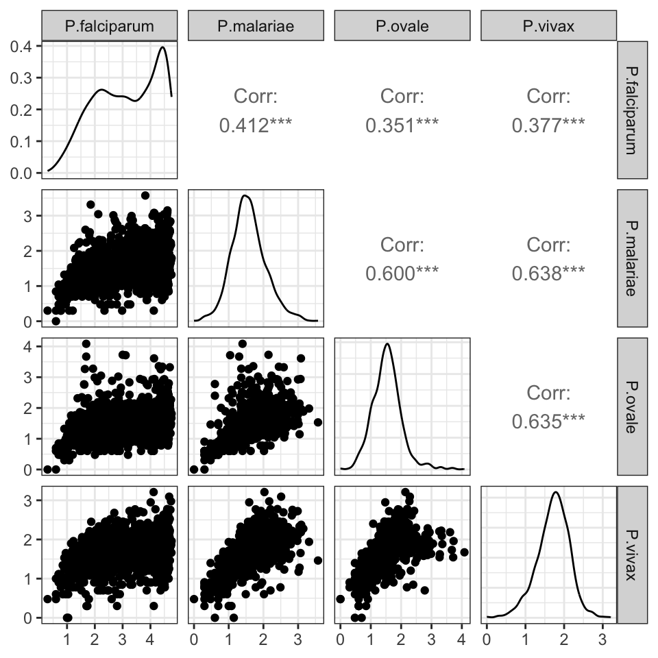

```r
ggpairs(log10(df[2:5]))
```

Priors for each model parameter follow a pre-specified distribution (see [O’Driscoll et al.](https://doi.org/10.1126/scitranslmed.ads8680)).

```r
priors <- list(
 mu0_mean = 3, mu0_sd = 0.1,    # Negative titers (normal distribution)
 mu1_mean = 3, mu1_sd = 0.5,    # Positive titers (normal distribution)
 sd0_mean = 1.5, sd0_sd = 0.05, # SD of negative titers (normal distribution)
 sd1_mean = 2, sd1_sd = 0.05,   # SD of positive titers (normal distribution)
 phi_rate = 8,                  # Cross-reactivity (exponential distribution)
 rho_a = 2, rho_b = 2           # Correlation (beta distribution)
)
```

## Set up cmdstanr

The model fitting is done in cmdstanr. Resources for setting up `cmdstanr` can be found [here](https://mc-stan.org/cmdstanr/articles/cmdstanr.html).

```r
library(cmdstanr)
# check cmdstan toolchain & set cmdstan path if needed
check_cmdstan_toolchain()
```

```
#> The C++ toolchain required for CmdStan is setup properly!
```

## Run MCMC

```r
# Compile the model
mod <- cmdstan_model(here("StanModels", "MultiSero_LocAge.stan"), pedantic = FALSE)

# Set output path
folder <- "comsa_mps119_res" # output subdirectory within Results/
```

```r
dir.create(here("Results", folder))

# run model
fit <- mod$sample(
 data = c(data, priors),
 chains = 3,
 parallel_chains = 3,
 iter_sampling = 3000,
 refresh = 100,
 iter_warmup = 3000,
 output_dir = here("Results", folder)
)
```

## Check MCMC diagnostics

We use `bayesplot` diagnostics to check that chains mix well and converge to a common posterior distribution. Note that the estimated prevalence and $\mu_1$ for *P. vivax* is set at 0 as it is not assumed to be present.

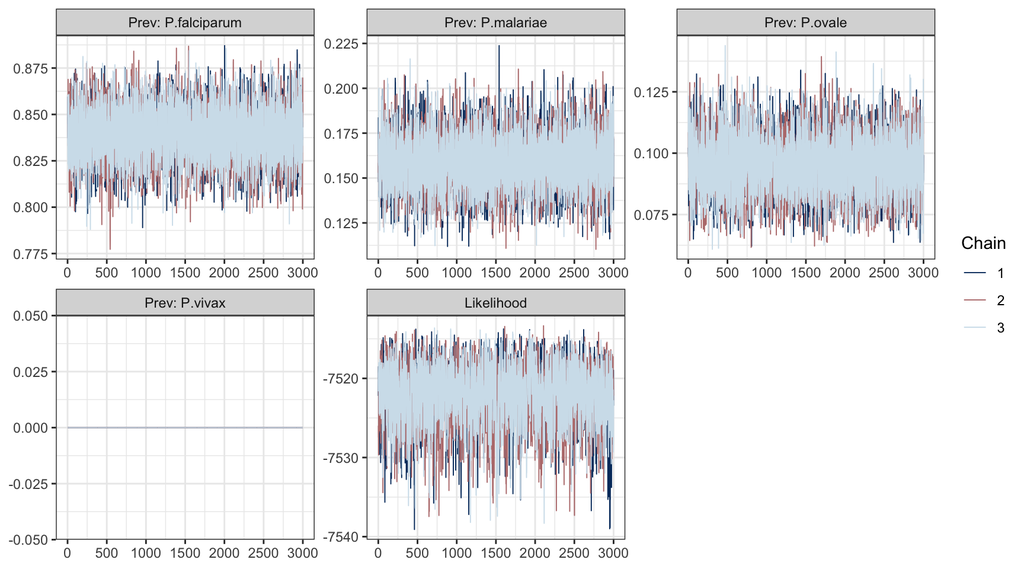

```r
# extract posterior draws
chains <- fit$draws(format = "df")

trace_df <- relabel_chains(chains = chains, pathogens, present)

color_scheme_set("mix-blue-red")

# Examine trace plots for key parameter groups
mcmc_trace(trace_df, pars = vars(starts_with("Prev"), "Likelihood"))
```

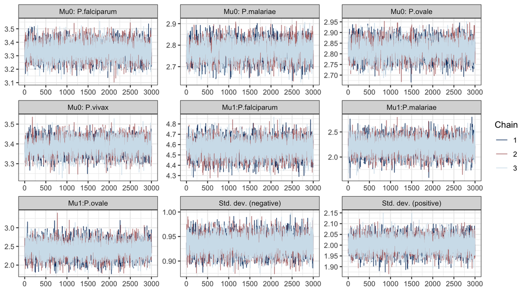

```r
mcmc_trace(trace_df, pars = vars(starts_with(c("Mu", "Std"))))
```

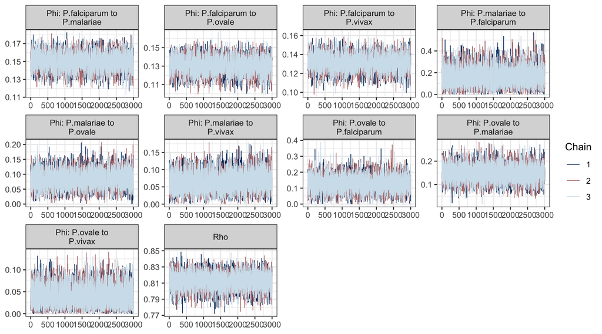

```r
mcmc_trace(trace_df, pars = vars(starts_with("Phi"), "Rho"))
```

In this run, chains appear well mixed and converged. If not, increase iterations and/or revisit priors.

# Extract model estimates

Once diagnostics are acceptable, we can summarize posterior estimates.

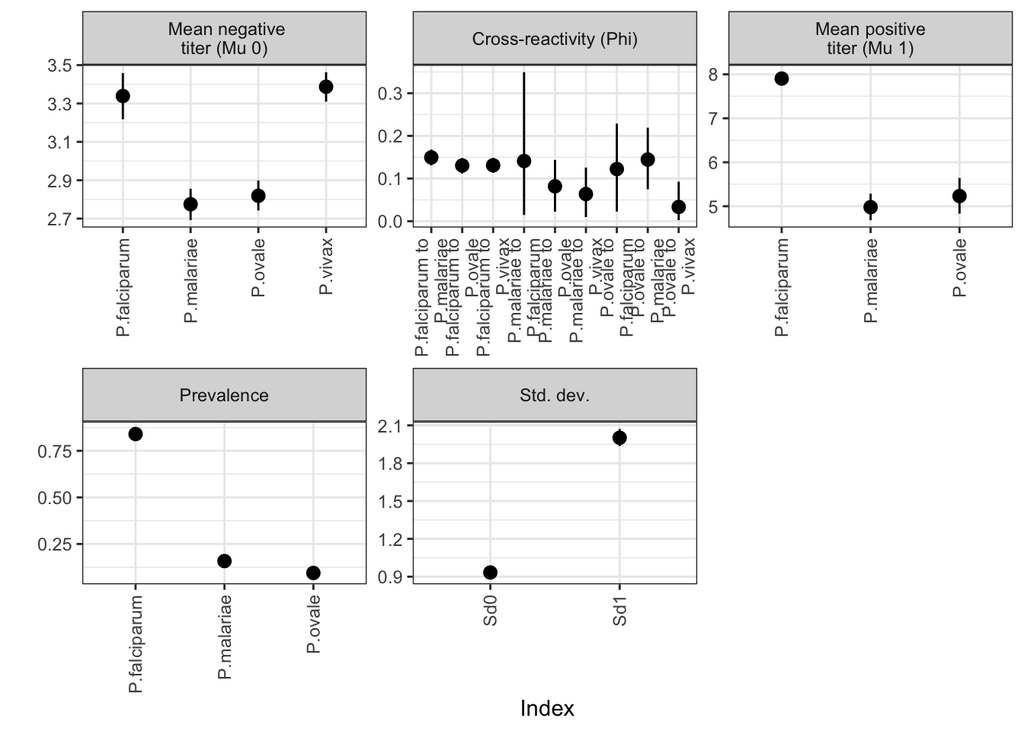

```r
posteriors <- get_posterior(as.data.frame(chains), data, pathogens)
posteriors$plot
```

```r
posteriors$table |> knitr::kable(digits = 3)
```

| par | med | ciL | ciU |
| --- | --- | --- | --- |
| mu0 P.falciparum | 3.339 | 3.218 | 3.458 |
| mu0 P.malariae | 2.775 | 2.692 | 2.856 |
| mu0 P.ovale | 2.819 | 2.742 | 2.898 |
| mu0 P.vivax | 3.387 | 3.310 | 3.463 |
| mu1 P.falciparum | 7.903 | 7.758 | 8.048 |
| mu1 P.malariae | 4.979 | 4.683 | 5.285 |
| mu1 P.ovale | 5.231 | 4.832 | 5.644 |
| Sd0 | 0.933 | 0.898 | 0.970 |
| Sd1 | 2.002 | 1.935 | 2.072 |
| Phi P.falciparum to P.malariae | 0.150 | 0.131 | 0.168 |
| Phi P.falciparum to P.ovale | 0.131 | 0.112 | 0.148 |
| Phi P.falciparum to P.vivax | 0.131 | 0.114 | 0.148 |
| Phi P.malariae to P.falciparum | 0.141 | 0.015 | 0.349 |
| Phi P.malariae to P.ovale | 0.082 | 0.022 | 0.144 |
| Phi P.malariae to P.vivax | 0.064 | 0.010 | 0.126 |
| Phi P.ovale to P.falciparum | 0.122 | 0.023 | 0.229 |
| Phi P.ovale to P.malariae | 0.145 | 0.075 | 0.219 |
| Phi P.ovale to P.vivax | 0.033 | 0.002 | 0.093 |
| Prev P.falciparum | 0.840 | 0.811 | 0.868 |
| Prev P.malariae | 0.158 | 0.130 | 0.190 |
| Prev P.ovale | 0.094 | 0.073 | 0.119 |

Looking first at prevalence, estimated exposure is highest for *P. falciparum* (median 0.840, 95% CrI 0.811-0.867), and much lower for the other two circulating strains: *P. malariae* (0.158, 0.130-0.191) and *P. ovale* (0.094, 0.074-0.117). These values can be interpreted as posterior probabilities of prior exposure in the sampled population, with credible intervals quantifying uncertainty.

The $\phi$ parameters describe how exposure to one species is expected to contribute to the antigen level of another speices. We see modest cross-reactivity from exposure to *P. falciparum* on the antibody level of *P. malariae* ($\phi$ = 0.149 [0.130-0.168]), *P. ovale* ($\phi$ = 0.130 [0.113-0.148]), and *P. vivax* *P. ovale* ($\phi$ = 0.131 [0.114-0.148]).